# R Notebook

Linear Regression Homework

```r
library(tidyverse)
library(janitor)
```

1. Read in the data

```r
project <- read_csv("data/project_management.csv") %>%
  clean_names()
class(project)
```

```
[1] "spec_tbl_df" "tbl_df"      "tbl"         "data.frame"
```

2. Plot the data using the estimated_length as the independent variable and the actual_length as the dependent variable.

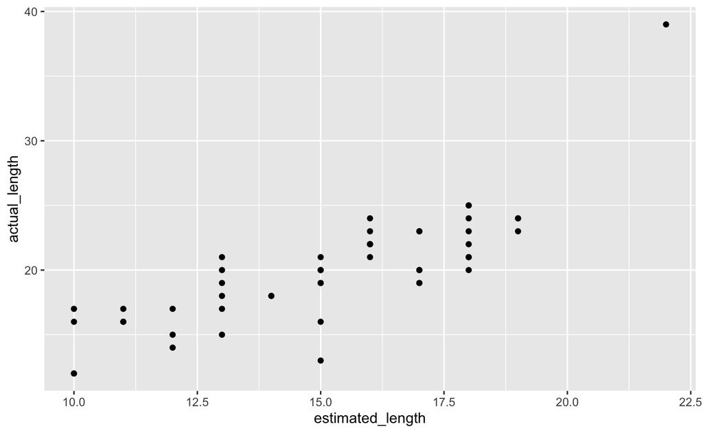

```r
project %>%
  ggplot(aes(estimated_length, actual_length)) +
  geom_point()
```

3. Calculate the correlation coefficient of estimated_length and actual_length and interpret the value you obtain.

This is a pretty strong correlation of 0.8, indicating a strong correlation between estimated and actual time spent on a building project.

```r
project %>%
  summarise(cor = cor(estimated_length, actual_length))
```

| cor |
| --- |
| 0.8046597 |

4. Perform a simple linear regression using actual_length as the dependent variable, and estimated_length as the independent variable. Save the model object to a variable.

So y is the dependent - outcome - variable (actual_length) And x is the independent - explanatory - variable (estimated_length)

```r
model <- lm(formula = actual_length ~ estimated_length, data = project)

summary(model)
```

```
Call:
lm(formula = actual_length ~ estimated_length, data = project)

Residuals:
    Min      1Q  Median      3Q     Max
-6.7687 -1.6513  0.1195  1.1252 10.6669

Coefficients:
                 Estimate Std. Error t value Pr(>|t|)
(Intercept)        1.4164     2.0069   0.706    0.484
estimated_length   1.2235     0.1303   9.389 1.91e-12 ***
---
Signif. codes:  0 ‘***’ 0.001 ‘**’ 0.01 ‘*’ 0.05 ‘.’ 0.1 ‘ ’ 1

Residual standard error: 2.606 on 48 degrees of freedom
Multiple R-squared:  0.6475,    Adjusted R-squared:  0.6401
F-statistic: 88.16 on 1 and 48 DF,  p-value: 1.911e-12
```

5. Interpret the regression coefficient of estimated_length (i.e. slope, gradient) you obtain from the model. How do you interpret the $r^2$ value reported by the model?

```r
library(broom)

glance(model)
```

| r.squared | adj.r.squared | sigma | statistic | p.value | df | logLik | AIC | BIC | deviance | df.residual | nobs |
| --- | --- | --- | --- | --- | --- | --- | --- | --- | --- | --- | --- |
| 0.6474772 | 0.640133 | 2.606163 | 88.16142 | 1.911284e-12 | 1 | -117.8203 | 241.6407 | 247.3767 | 326.0201 | 48 | 50 |

6. Is the relationship statistically significant? Remember, to assess this you need to check the $p$-value of the regression coefficient (or slope/gradient). But you should first check the regression diagnostic plots to see if the $p$-value will be reliable (don’t worry about any outlier points you see in the diagnostic plots, we’ll return to them in the extension).

The p value is statistically significant for the regression coefficient. The residuals vs fitted diagnostic plot looks reliable as it is close to 0 and does not stray too far from it until the end. The normal Q-Q diagnostic plot follows the line, indicating it too is reliable. The scale-location also appears reliable.

[output not shown]

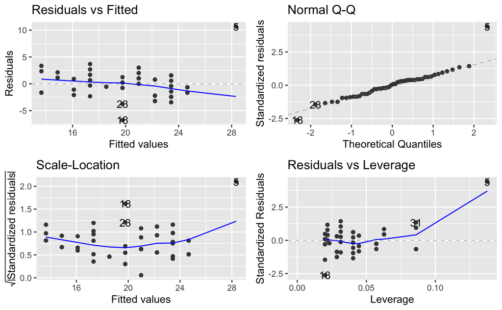

```r
library(ggfortify)
autoplot(model)
```

Extension

1. Return to your plot from earlier, and now label the data points with their row number in the data frame using geom_text() [Hint - you can pass aes(label = 1:nrow(project)) to this layer to generate row index labels] Identify by eye any points you think might be outliers and note their labels. Further split your outliers into those you think are ‘influential’ or ‘non-influential’ based on a visual assessment of their leverage.

It appears that the outlier of row 5 would have quite a lot of leverage and may be influential. I do not see any other outliers that would have influence to the same extent but 18 is quite low compared to the other observations.

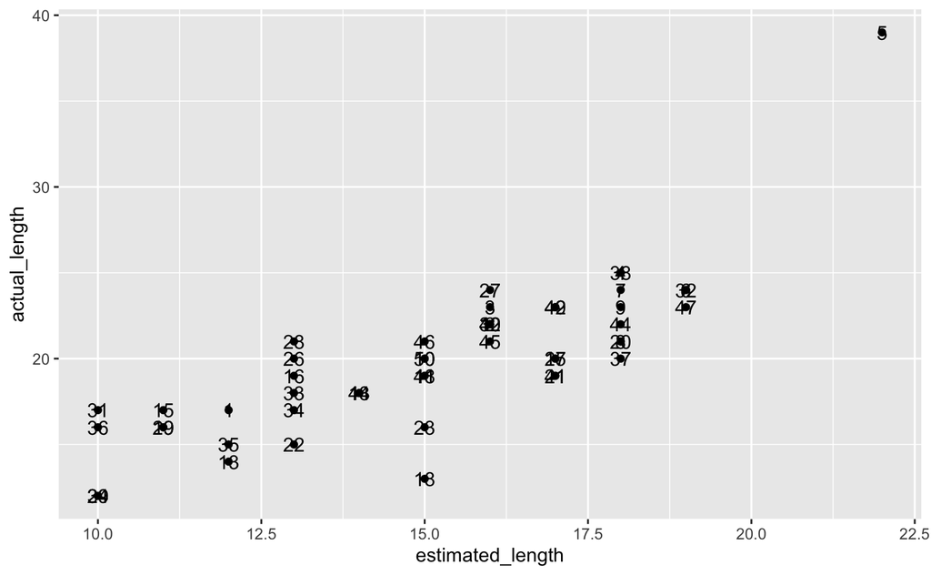

```r
project %>%
  ggplot(aes(estimated_length, actual_length)) +
  geom_point() +
  geom_text(aes(label = 1:nrow(project)))
```

Use your model object from earlier and confirm your visual assessment of which points are ‘influential’ or ‘non-influential’ outliers based on Cook’s distance. You can get a useful plot of Cook’s distance by passing argument which = 4 to autoplot(). Or try the base R plot() function for comparison [e.g. plot(model); you can also use par(mfrow = c(2,2)) just before the plot() command to get a nice two-by-two display]!

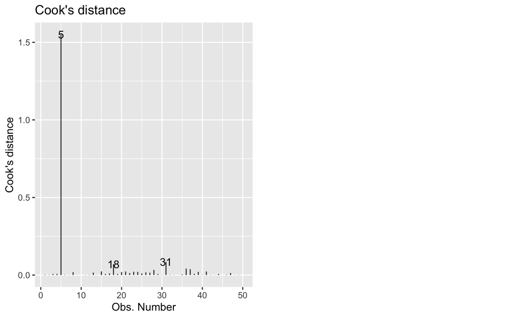

```r
autoplot(model, which = 4)
```

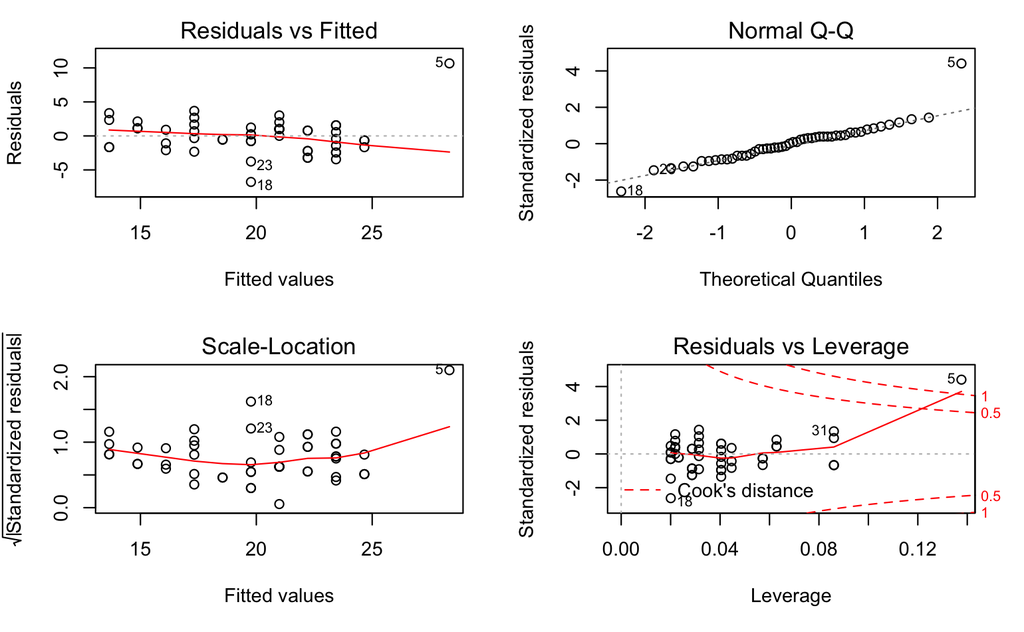

```r
par(mfrow = c(2, 2))
plot(model)
```

[output not shown]

[output cut: 39 more lines]

3. Obtain the intercept and regression coefficient of variable estimated_length for a simple linear model fitted to data omitting one of your non-influential outlier points. How different are the intercept and coefficient from those obtained above by fitting the full data set? Does this support classifying the omitted point as non-influential? Plot the data points, this regression line and the regression line for the full data set. How different are the lines?

The intercept and coefficient are not that different at all. This supports the omitted point as not influential.

The two lines are not really visibly different. They both start under 20 and end just under 30.

```r
model_dropped <- lm(formula = actual_length ~ estimated_length, data =
                      project_dropped)

summary(model_dropped)
```

```
Call:
lm(formula = actual_length ~ estimated_length, data = project_dropped)

Residuals:
    Min      1Q  Median      3Q     Max
-6.7283 -1.6329  0.0526  1.1480 10.7382

Coefficients:
                 Estimate Std. Error t value Pr(>|t|)
(Intercept)         1.442      2.016   0.715    0.478
estimated_length    1.219      0.131   9.308 3.08e-12 ***
---
Signif. codes:  0 ‘***’ 0.001 ‘**’ 0.01 ‘*’ 0.05 ‘.’ 0.1 ‘ ’ 1

Residual standard error: 2.617 on 47 degrees of freedom
Multiple R-squared:  0.6483,    Adjusted R-squared:  0.6408
F-statistic: 86.64 on 1 and 47 DF,  p-value: 3.076e-12
```

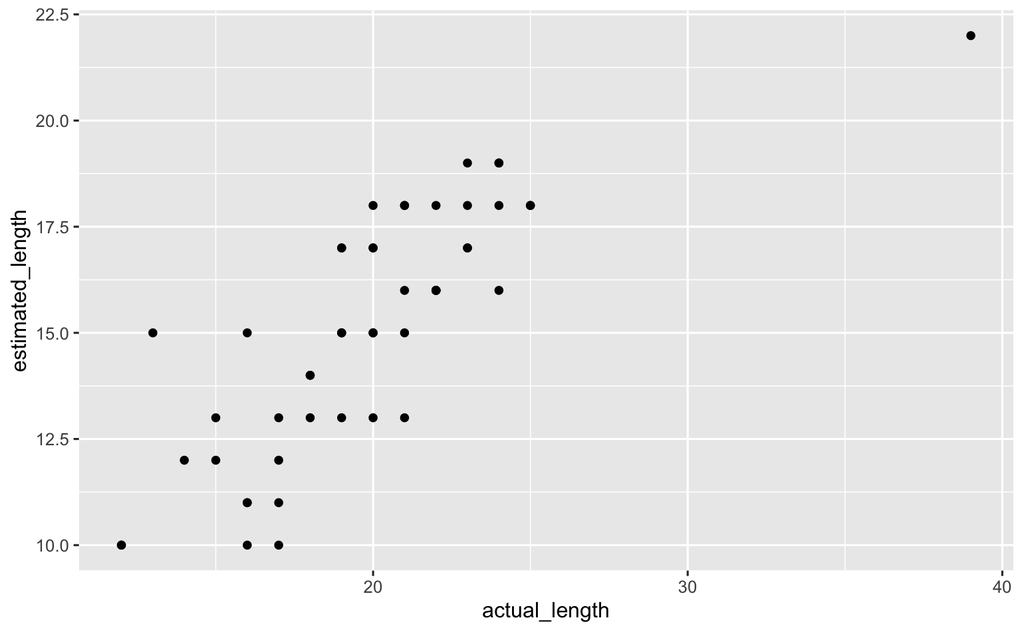

```r
model_dropped %>%
  ggplot(aes(actual_length, estimated_length)) +
  geom_point()
```

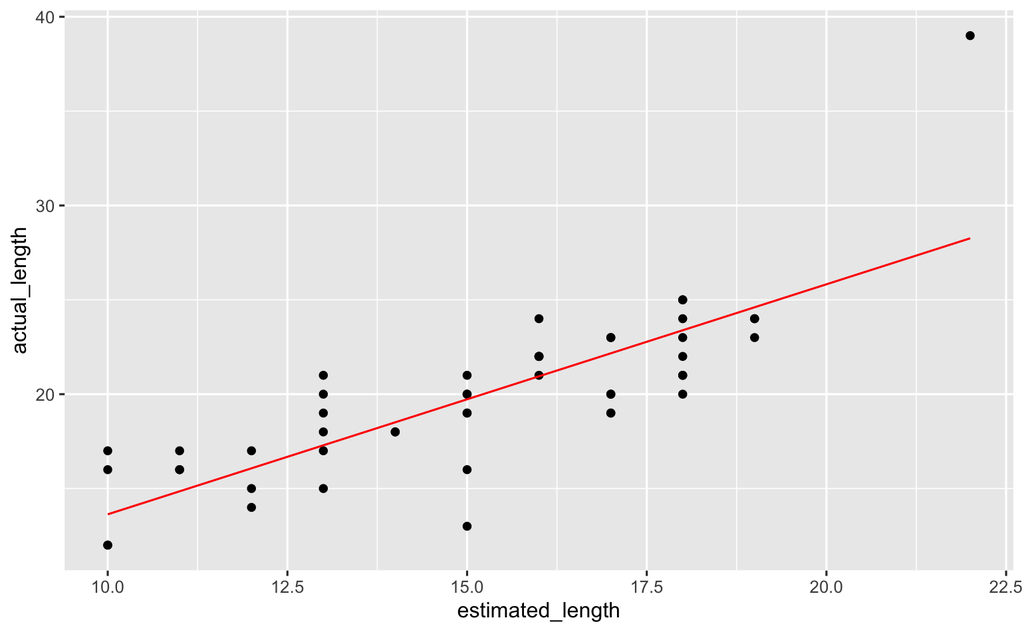

```r
library(modelr)

project_dropped <- project_dropped %>%
  add_predictions(model_dropped) %>%
  add_residuals(model_dropped)

project_dropped %>%
  ggplot(aes(x = estimated_length)) +
  geom_point(aes(y = actual_length)) +
  geom_line(aes(y = pred), col = "red")
```

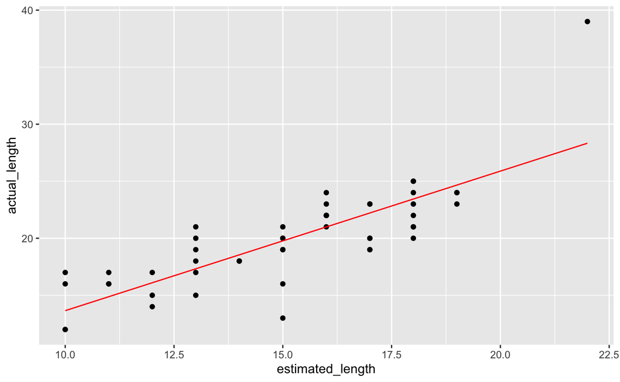

```r
project <- project %>%
  add_predictions(model) %>%
  add_residuals(model)

project %>%
  ggplot(aes(x = estimated_length)) +
  geom_point(aes(y = actual_length)) +
  geom_line(aes(y = pred), col = "red")
```

Repeat the procedure above, but this time omitting one of your influential outliers.

```r
project_leverage <- project %>%
  slice(-c(5))
```

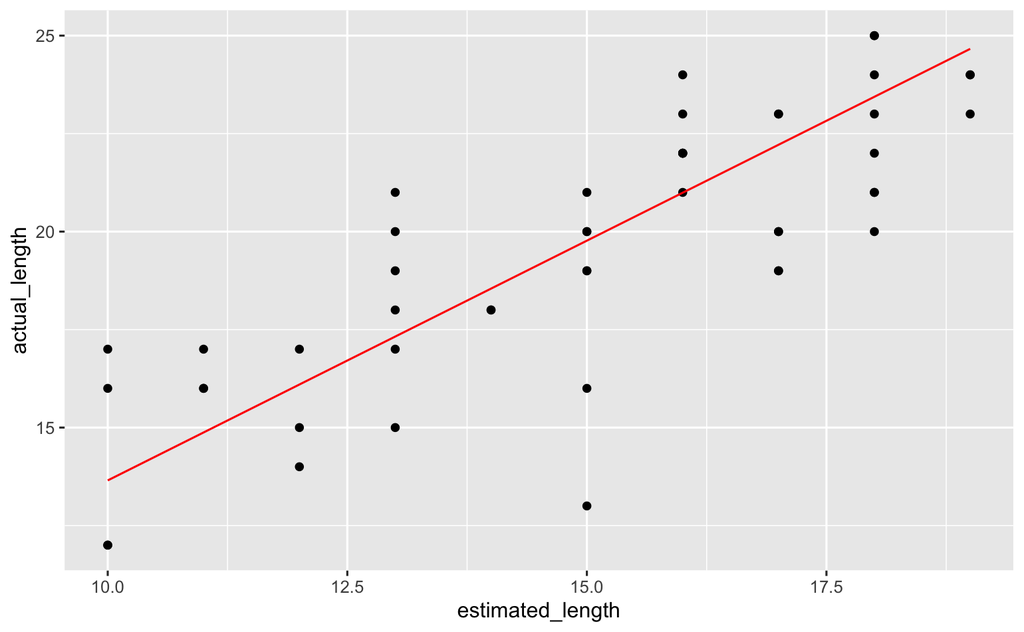

```r
project_leverage <- project_leverage %>%
  add_predictions(model) %>%
  add_residuals(model)

project_leverage %>%
  ggplot(aes(x = estimated_length)) +
  geom_point(aes(y = actual_length)) +
  geom_line(aes(y = pred), col = "red")
```